# Diagramas de dispersion en el análisis de datos

```python
import pandas as pd
import seaborn as sns
import matplotlib.pyplot as plt

#Configurando Latex
# Configuración de Matplotlib para usar LaTeX
plt.rcParams.update({
    "text.usetex": True,
    "font.family": "serif",
    "font.serif": ["Computer Modern Roman"],
    "text.latex.preamble": r"\usepackage{amsmath}"
})

iris = sns.load_dataset('iris')
#Dataset de Flores
iris.head(3)
```

|  | sepal_length | sepal_width | petal_length | petal_width | species |
| --- | --- | --- | --- | --- | --- |
| 0 | 5.1 | 3.5 | 1.4 | 0.2 | setosa |
| 1 | 4.9 | 3.0 | 1.4 | 0.2 | setosa |
| 2 | 4.7 | 3.2 | 1.3 | 0.2 | setosa |

El data set tiene atributos que se miden en la flor Iris y entonces tenemos que dependiendo de la longitud de 2 elementos fundamentales; pétalo y sepalo podemos clasificar a que especie corresponden.

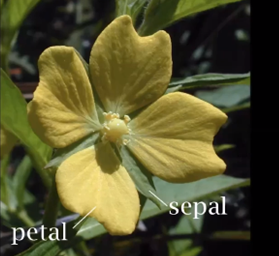

Vamos a trabajar con la gráfica scatterplot.

```python
iris.columns
```

```
Index(['sepal_length', 'sepal_width', 'petal_length', 'petal_width',
       'species'],
      dtype='object')
```

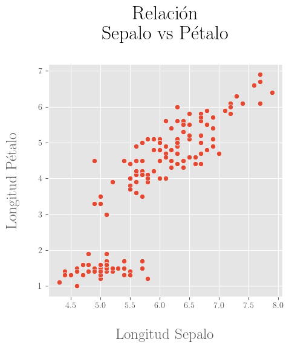

```python
#Definiendo estilos
plt.style.use('ggplot')
fig, ax = plt.subplots(figsize=(5,5))

sns.scatterplot(data=iris,x='sepal_length',y='petal_length')
plt.title('Relación\nSepalo vs Pétalo\n',fontsize=23)
plt.xlabel('\nLongitud Sepalo',fontsize=18)
plt.ylabel('Longitud Pétalo\n',fontsize=18)
```

Esta gráfica dibuja un punto por flor y la intersección entre ambas medidas **(longitud del sepalo y longitud del pétalo)** es donde se ubica el punto. Este tipo de visualización nos muestra la relación de los datos. Aquí están combinadas todas las especies.

Hagamos una segmentación de especies.

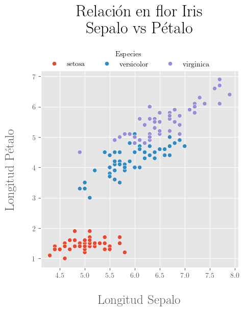

```python
#Definiendo estilos
plt.style.use('ggplot')
fig, ax = plt.subplots(figsize=(5,5))

sns.scatterplot(data=iris,x='sepal_length',y='petal_length',hue='species')
plt.title('Relación en flor Iris\nSepalo vs Pétalo\n\n',fontsize=23)
plt.xlabel('\nLongitud Sepalo',fontsize=18)
plt.ylabel('Longitud Pétalo\n',fontsize=18)
sns.move_legend(ax, "upper left", bbox_to_anchor=(0, 1.13),ncol=3,title='Especies',frameon=False)
```

Aquí en este gráfico se percibe una relación mas clara sobre los 3 tipos de especies y el tamaño de sus parámetros, por ejemplo podemos observar que las tipo **setosa** tienen la menor *longitud en sepalo* y de igual forma la menor *longitud de pétalo*.

A continuación usaremos Joinplot.

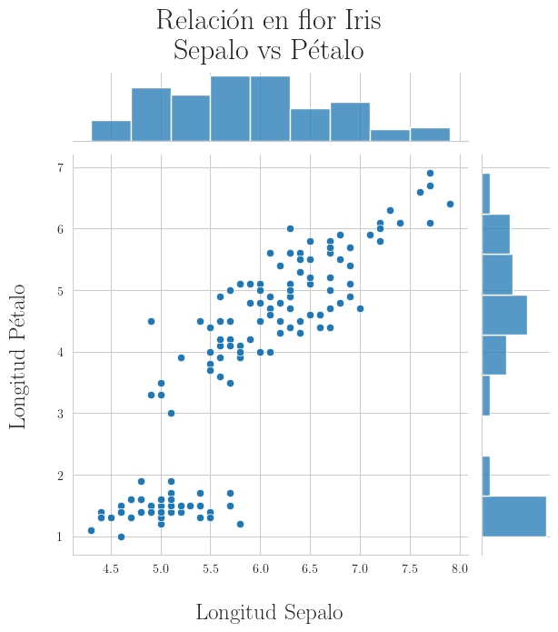

```python
#Definiendo estilos
plt.style.use('default')
plt.rcParams.update({
    "text.usetex": True,
    "font.family": "serif",
    "font.serif": ["Computer Modern Roman"],
    "text.latex.preamble": r"\usepackage{amsmath}"
})

with sns.axes_style("whitegrid"):
    sns.jointplot(data=iris,x='sepal_length',y='petal_length')
    plt.title('Relación en flor Iris\nSepalo vs Pétalo\n\n\n',fontsize=23)
    plt.xlabel('\nLongitud Sepalo',fontsize=18)
    plt.ylabel('Longitud Pétalo\n',fontsize=18)
```

Como se puede observar este tipo de visualización combina 2 gráficas, en este caso arrojó un scatterplot y 2 histogramas para cada eje.

Ahora agregaremos una segmentación de especies.

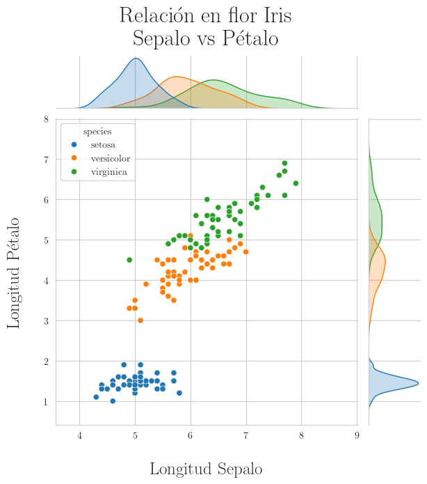

```python
#Definiendo estilos
plt.style.use('default')
plt.rcParams.update({
    "text.usetex": True,
    "font.family": "serif",
    "font.serif": ["Computer Modern Roman"],
    "text.latex.preamble": r"\usepackage{amsmath}"
})

with sns.axes_style("whitegrid"):
    sns.jointplot(data=iris,x='sepal_length',y='petal_length',hue='species')
    plt.title('Relación en flor Iris\nSepalo vs Pétalo\n\n\n',fontsize=23)
    plt.xlabel('\nLongitud Sepalo',fontsize=18)
    plt.ylabel('Longitud Pétalo\n',fontsize=18)
```

Como podemos observar, aquí se cambio el tipo de gráfica en los ejes y esto es debido a la segmentación. También podemos apreciar en los diferentes ejes que las distribuciones de los diversos datos, en algunos casos pueden parecer uniformes y en otros no parecen asi.

También podemos comparar las demás variables.

```python
#Veremos que columnas disponibles tenemos
iris.columns
```

```
Index(['sepal_length', 'sepal_width', 'petal_length', 'petal_width',
       'species'],
      dtype='object')
```

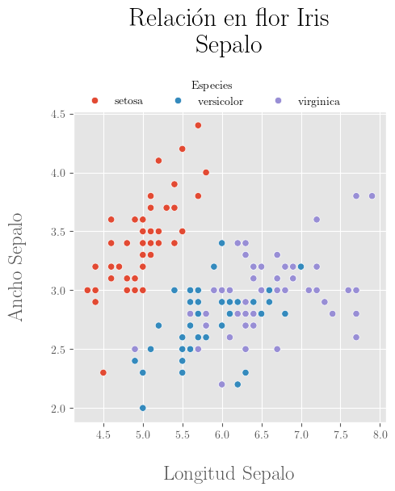

```python
#Definiendo estilos
plt.style.use('ggplot')
fig, ax = plt.subplots(figsize=(5,5))

sns.scatterplot(data=iris,x='sepal_length',y='sepal_width',hue='species')
plt.title('Relación en flor Iris\nSepalo\n\n',fontsize=23)
plt.xlabel('\nLongitud Sepalo',fontsize=18)
plt.ylabel('Ancho Sepalo\n',fontsize=18)
sns.move_legend(ax, "upper left", bbox_to_anchor=(0, 1.13),ncol=3,title='Especies',frameon=False)
```

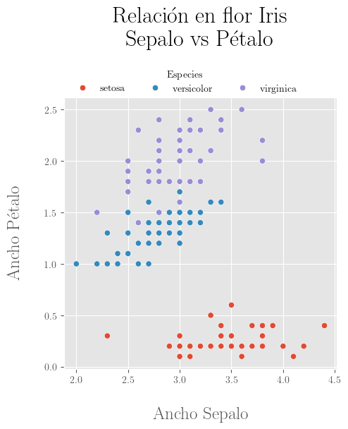

```python
#Definiendo estilos
plt.style.use('ggplot')
fig, ax = plt.subplots(figsize=(5,5))

sns.scatterplot(data=iris,x='sepal_width',y='petal_width',hue='species')
plt.title('Relación en flor Iris\nSepalo vs Pétalo\n\n',fontsize=23)
plt.xlabel('\nAncho Sepalo',fontsize=18)
plt.ylabel('Ancho Pétalo\n',fontsize=18)
sns.move_legend(ax, "upper left", bbox_to_anchor=(0, 1.13),ncol=3,title='Especies',frameon=False)
```

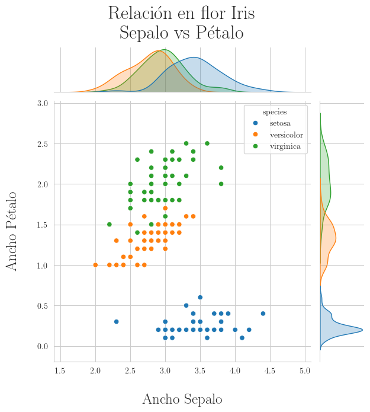

```python
#Definiendo estilos
plt.style.use('default')
plt.rcParams.update({
    "text.usetex": True,
    "font.family": "serif",
    "font.serif": ["Computer Modern Roman"],
    "text.latex.preamble": r"\usepackage{amsmath}"
})

with sns.axes_style("whitegrid"):
    sns.jointplot(data=iris,x='sepal_width',y='petal_width',hue='species')
    plt.title('Relación en flor Iris\nSepalo vs Pétalo\n\n\n',fontsize=23)
    plt.xlabel('\nAncho Sepalo',fontsize=18)
    plt.ylabel('Ancho Pétalo\n',fontsize=18)
```

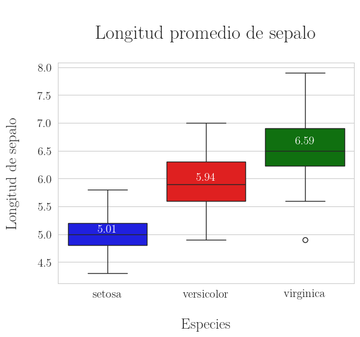

```python
#Box plot
with sns.axes_style("whitegrid"):
    sns.boxplot(x='species',y='sepal_length',data=iris,palette=['blue','red','green'])
    plt.title('\nLongitud promedio de sepalo\n',fontsize=23)
    plt.xlabel('\nEspecies',fontsize=18)
    plt.ylabel('Longitud de sepalo\n',fontsize=18)

    for index, row in Species_averages_sl.iterrows():
        plt.text(index, row['sepal_length'] + .03, f'{row["sepal_length"]:.2f}', color='white', ha="center")
```

```python
Species_averages_sl = iris.groupby(by='species')['sepal_length'].mean().reset_index()
Species_averages_sw = iris.groupby(by='species')['sepal_width'].mean().reset_index()
Species_averages_pl = iris.groupby(by='species')['petal_length'].mean().reset_index()
Species_averages_pw = iris.groupby(by='species')['petal_width'].mean().reset_index()
iris.groupby(by='species').mean()
```

| species | sepal_length | sepal_width | petal_length | petal_width |
| --- | --- | --- | --- | --- |
| setosa | 5.006 | 3.428 | 1.462 | 0.246 |
| versicolor | 5.936 | 2.770 | 4.260 | 1.326 |
| virginica | 6.588 | 2.974 | 5.552 | 2.026 |

En la tabla anterior podemos afirmar nuestra hipótesis que teníamos sobre los promedios en **longitud del sepalo de cada especie**

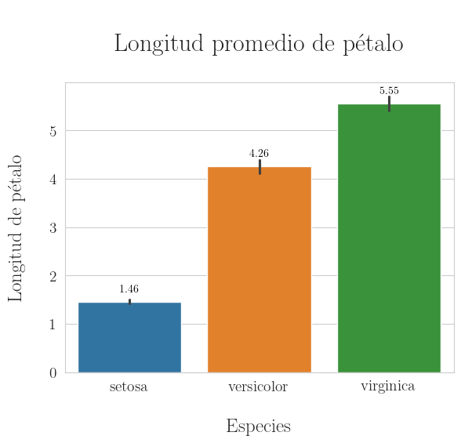

```python
#Longitud promedio de pétalo
with sns.axes_style("whitegrid"):
    sns.barplot(x='species',y='petal_length',data=iris,hue='species')
    plt.title('\nLongitud promedio de pétalo\n',fontsize=23)
    plt.xlabel('\nEspecies',fontsize=18)
    plt.ylabel('Longitud de pétalo\n',fontsize=18)
    for index, row in Species_averages_pl.iterrows():
        plt.text(index, row['petal_length'] + .2, f'{row["petal_length"]:.2f}', color='black', ha="center",fontsize=10)
```

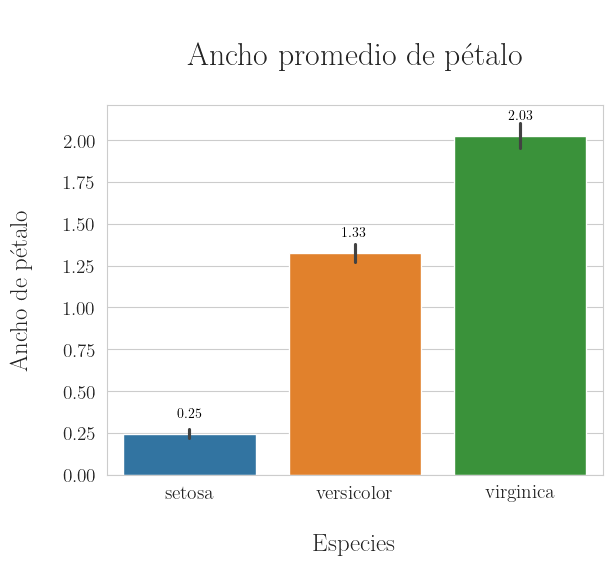

```python
#Ancho promedio de pétalo
with sns.axes_style("whitegrid"):
    sns.barplot(x='species',y='petal_width',data=iris,hue='species')
    plt.title('\nAncho promedio de pétalo\n',fontsize=23)
    plt.xlabel('\nEspecies',fontsize=18)
    plt.ylabel('Ancho de pétalo\n',fontsize=18)
    for index, row in Species_averages_pw.iterrows():
        plt.text(index, row['petal_width'] + .1, f'{row["petal_width"]:.2f}', color='black', ha="center",fontsize=10)
```

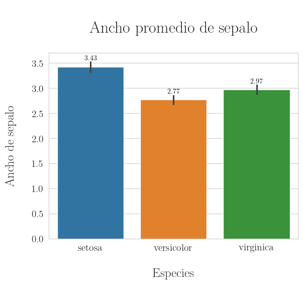

```python
#Ancho promedio de sepalo
with sns.axes_style("whitegrid"):
    sns.barplot(x='species',y='sepal_width',data=iris,hue='species')
    plt.title('\nAncho promedio de sepalo\n',fontsize=23)
    plt.xlabel('\nEspecies',fontsize=18)
    plt.ylabel('Ancho de sepalo\n',fontsize=18)

    for index, row in Species_averages_sw.iterrows():
        plt.text(index, row['sepal_width'] + .13, f'{row["sepal_width"]:.2f}', color='black', ha="center",fontsize=10)
```

## Extras

https://seaborn.pydata.org/tutorial/properties.html#text